# Netlogo Turtle Spatial Projection

Aimara Planillo

2023-06-15

# How to project Netlogo Turtle coordinates into a real map

After running a model, usually we want to reproject the output back to the spatial data coordinates used, either for post-simulation analyses or for plotting.

This code shows how to project the turtles’ coordinates back into a map, when a raster was used to create the Netlogo landscape.

For this we need: - The raster used as netlogo input - The turtle coordinates in the output

## 0. Load libraries

```r
library(terra)
library(dplyr)
library(sf)
library(tmap)
library(ggplot2)
library(ggspatial)
```

## 1. Create data

In this example we create a raster and some turtle data to use. With real data, you will load your raster here and make sure it has a PROJECTED coordinate system. Turtle data will have different formats depending how it was created, the basic data we need for this is the identity of the turtle and the coordinates.

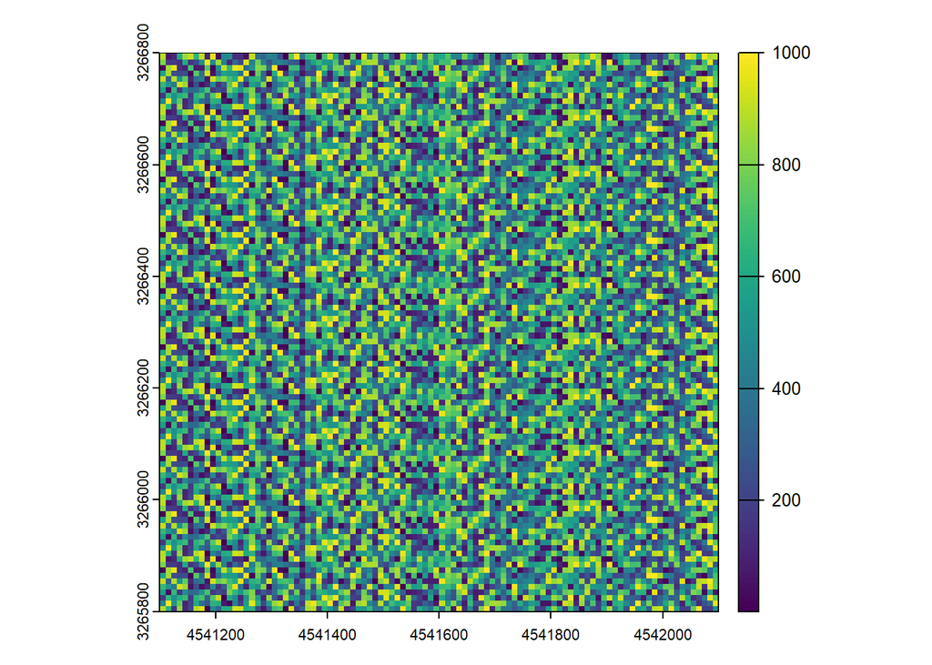

```r
## Create raster with 100 cells for the example
myraster <- rast(nrows = 100, ncols = 100,
                 xmin = 4541100, xmax = 4542100,
                 ymin = 3265800, ymax = 3266800)
## give random values to the raster
myraster <- init(myraster, sample(1:1000))

## assign projection
crs(myraster) <- "epsg:3035"
plot(myraster)
```

```r
## turtle data - example data
who <- seq(1,10)
xcoord <- sample(1:100, 10) # create random integers for x coordinate
ycoord <- sample(1:100, 10) # create random integers for y coordinate

turtle_variables <- cbind.data.frame(who, xcoord, ycoord)
head(turtle_variables)
```

```
##   who xcoord ycoord
## 1   1     73      5
## 2   2      6     51
## 3   3     53     21
## 4   4     63     23
## 5   5     21     67
## 6   6     96     44
```

Now that we have our data, let’s extract the map coordinates as reference and transform the turtle ones. This process will work with any PROJECTED coordinate system.

## 2. Get reference coordinates

We need the bottom left corner of the map as a reference point and the resolution of the map

```r
# we are going to trasnform the cell relative numbering to real coordinates, starting left down as this is where netlogo starts numbering the cells
start_left <- xmin(myraster)
start_down <- ymin(myraster)
my_res <- res(myraster)[1]
```

## 3. Transform turtle coordinates into map coordinates

Now we use the reference point to transform our coordinates into the projected coordinates and the resolution to correct for the size of the cells

```r
turtle_spatial <- turtle_variables %>%
  mutate(spatial_xcoord = start_left + ((xcoord * my_res) + my_res/2), #divided by 2 to locate in the center of the cell
         spatial_ycoord = start_down + ((ycoord * my_res) + my_res/2))


## make spatial points
turtle_sf <- st_as_sf(turtle_spatial,
                      coords = c("spatial_xcoord", "spatial_ycoord"),
                      crs = crs(myraster))
```

## 4. Quick plot with tmap

```r
tmap_mode("view")
tm_shape(myraster) +
  tm_raster(palette = viridis::viridis(10), alpha = 0.2) +
  tm_shape(turtle_sf) +
  tm_dots("black", size = 0.2)
```

[interactive chart not shown]

## 5. Plot with ggplot2

```r
## make myraster a dataframe
map_df <- as.data.frame(myraster, xy = TRUE)
names(map_df) <- c("x","y","hs")
head(map_df)
```

```
##         x       y  hs
## 1 4541105 3266795 895
## 2 4541115 3266795  69
## 3 4541125 3266795 113
## 4 4541135 3266795 610
## 5 4541145 3266795 856
## 6 4541155 3266795 901
```

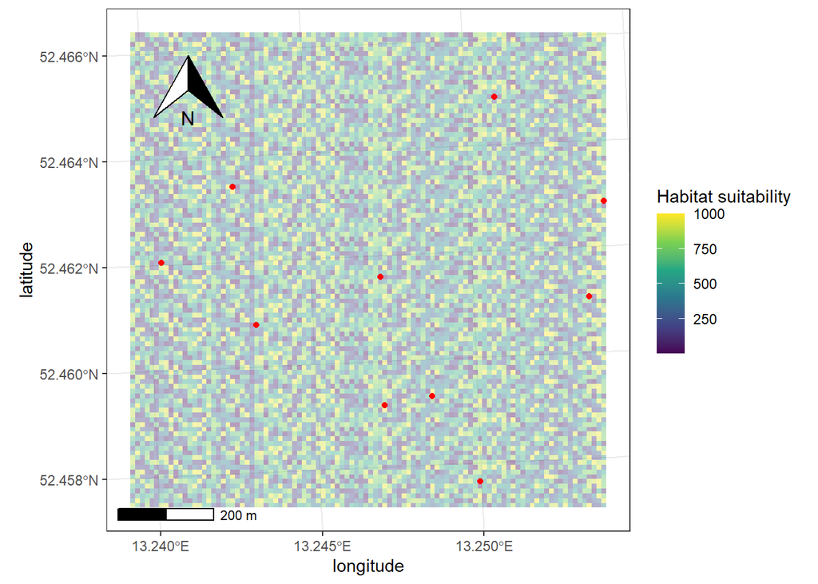

```r
## plot map with turtles on top
plot_mymap <- ggplot() +
  geom_tile(data = map_df, aes(x = x, y = y, fill = hs), alpha = 0.4) +
  scale_fill_viridis_c(na.value = "transparent",
                       name = "Habitat suitability") +
  geom_sf(data = turtle_sf, col = "red") +
  annotation_scale() +
  annotation_north_arrow(location = "tl",
    pad_x = unit(0.4, "in"), pad_y = unit(0.4, "in")) +
  ylab("latitude") +
  xlab("longitude") +
  theme_bw() +
  theme(
    plot.background = element_blank()
  )

plot_mymap
```